# Geospatial risk modeling - the case of crime

## 5.3 Model error by random k-fold and spatial cross validation

Below maps indicate the prediction errors by random k-fold and spatial cross validation. It is notable to indicate the Spatial Structure can decrease the errors.

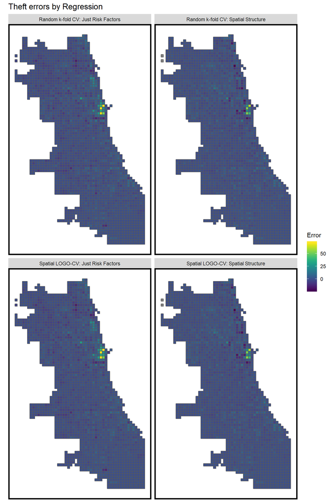

```r
filter(reg.summary, Regression == "Spatial LOGO-CV: Just Risk Factors" |
         Regression == "Spatial LOGO-CV: Spatial Structure" |
         Regression == "Random k-fold CV: Just Risk Factors" |
         Regression == "Random k-fold CV: Spatial Structure" ) %>%
  ggplot() +
    geom_sf(aes(fill = Error)) +
    facet_wrap(~Regression) +
    scale_fill_viridis() +
    labs(title = "Theft errors by Regression") +
    mapTheme()
```

## 5.4 MAE and the standard deviation of MAE

Mean absolute error (MAE) can be calculated on predicted and observed theft crime counts, then compared across models.The results indicate that the Spatial Structure model can decrease the MAE and SD_MAE. So,the regressions with the spatial structural features are much more accurate and more generalizable. These features are doing a better job predicting the hotspots.

```r
st_set_geometry(reg.summary, NULL) %>%
  group_by(Regression) %>%
  summarize(MAE = round(mean(abs(Prediction - counttheft), na.rm = T),2),
            SD_MAE = round(sd(abs(Prediction - counttheft), na.rm = T),2)) %>%
  kable(caption = "MAE by regression") %>%
    kable_styling("striped", full_width = F) %>%
    row_spec(2, color = "black", background = "#FDE725FF") %>%
    row_spec(4, color = "black", background = "#FDE725FF")
```

MAE by regression

| Regression | MAE | SD_MAE |
| --- | --- | --- |
| Random k-fold CV: Just Risk Factors | 2.02 | 3.84 |
| Random k-fold CV: Spatial Structure | 1.67 | 2.98 |
| Spatial LOGO-CV: Just Risk Factors | 2.06 | 3.95 |
| Spatial LOGO-CV: Spatial Structure | 1.68 | 3.01 |